# STAT 216: Introduction to Statistics

Summer 2026 Syllabus

# Instructor contact information

**Summer Session I:** Jeremiah Pharr, Lauren Gamber, Bernard Sefah

**Summer Session II:** Madison Alderman, Turner Haugen, Gideon Addo

## Pharr

[**Jeremiah Pharr**](https://math.montana.edu/directory/faculty/2323177/jeremiah-pharr)

email: jeremiahpharr@montana.edu

office: Wilson 1-112

## Gamber

**Lauren Gamber**

email: laurengamber@montana.edu

office: Wilson 2-245

## Sefah

**Bernard Sefah**

email: bernard.sefah@montana.edu

office: Wilson 2-232

## Alderman

[**Madison Alderman**](https://www.math.montana.edu/directory/faculty/2633272/madison-alderman)

email: madisonalderman1@montana.edu

office: Wilson 1-112

## Haugen

**Turner Haugen**

email: turner.haugen@montana.edu

office: Wilson 1-136

## Addo

**Gideon Addo**

email: gideonaddo@montana.edu

office: Wilson 1-136

# Course calendars

- STAT 216 Summer I calendar
- STAT 216 Summer II calendar
- [Summer registration calendar](https://www.montana.edu/registrar/add_drop_schedule.html)

# Course description

Stat 216 is designed to engage you in the statistical investigation process from developing a research question and data collection methods to analyzing and communicating results. This course introduces basic descriptive and inferential statistics using both traditional (normal and $t$-distribution) and simulation approaches including confidence intervals and hypothesis testing on means (one-sample, two-sample, paired), proportions (one-sample, two-sample), regression and correlation. You will be exposed to numerous examples of real-world applications of statistics that are designed to help you develop a conceptual understanding of statistics. After taking this course, you should be able to:

- Understand and appreciate how statistics affects your daily life and the fundamental role of statistics in all disciplines.
- Evaluate statistics and statistical studies you encounter in your other courses.
- Critically read news stories based on statistical studies as an informed consumer of data.
- Assess the role of randomness and variability in different contexts.
- Use basic methods to conduct and analyze statistical studies using statistical software.
- Evaluate and communicate answers to the four pillars of statistical inference: How strong is the evidence of an effect? What is the size of the effect? How broadly do the conclusions apply? Can we say what caused the observed difference?

### MUS STAT 216 learning outcomes

1. Understand how to describe the characteristics of a distribution.
2. Understand how data can be collected, and how data collection dictates the choice of statistical method and appropriate statistical inference.
3. Interpret and communicate the outcomes of estimation and hypothesis tests in the context of a problem.
4. To understand the scope of inference for a given dataset.

### CORE 2.0

This course fulfills the Quantitative Reasoning (Q) CORE 2.0 requirement because learning probability and statistics allows us to disentangle what’s really happening in nature from “noise” inherent in data collection. It allows us to evaluate claims from advertisements and results of polls and builds critical thinking skills which form the basis of statistical inference. Students completing a Core 2.0 Quantitative Reasoning (Q) course should demonstrate an ability to:

Interpret and draw inferences from mathematical models such as formulas, graphs, diagrams or tables. Represent mathematical information numerically, symbolically and visually. Employ quantitative methods in symbolic systems such as, arithmetic, algebra, or geometry to solve problems.

# Prerequisites

Entrance to STAT 216 requires at least one of the following be met:

- Grade of C- or better in a 100-level math course (or equivalent)
- Grade of B or better in MATH 096
- Level 30 on the [Math Placement Exam](http://www.montana.edu/testing/MPLEX.html) or a combination of a good score on Math portion of SAT (540 or higher) or ACT (23 or higher) and/or good high school GPA
  - See the [Math Prerequisite Flowchart](http://www.math.montana.edu/undergrad/documents/MHiearchyFlowchart.pdf) for more details.

You should have familiarity with computers and technology (e.g., Internet browsing, word processing, opening/saving files, converting files to PDF format, sending and receiving e-mail, etc.).

# Course materials and resources

### Online textbook and coursepack

Two “textbooks” are required for this course:

1. [*Montana State Introductory Statistics with R*](https://mtstateintrostats.github.io/IntroStatTextbook/) — our free, online textbook
2. STAT 216 Coursepack — available for purchase from the MSU Bookstore

### RStudio

We will be using the statistical software [R](https://www.r-project.org/) through the IDE [RStudio](https://rstudio.com/products/rstudio/) for data visualization and statistical analyses.

You will access this software through the MSU RStudio server: [rstudio.math.montana.edu](https://rstudio.math.montana.edu/). Your username is your NetID email address (in the form x11x123@student.montana.edu), and your password is the password associated with your NetID.

- Please note: Your NetID password expires every 6 months. It is HIGHLY recommended that you reset your NetID password BEFORE attempting to log in to the RStudio server. You can reset your NetID password in the [MSU password portal](https://pwreset.montana.edu/react/).

See the [Statistical Computing](https://mtstateintrostats.github.io/IntroStatTextbook/rstudio.html#alternative-options-for-accessing-rstudio) section in the Welcome chapter of our textbook for alternative options for accessing RStudio.

### Required course software

All students are required to have a word processor and spreadsheet software installed on the personal device they plan to use for this course. We *highly* recommend the use of Word and Excel. If you do not currently have Word and/or Excel installed on your device, you can download the Microsoft Office 365 for Students for free by following the instructions [here](https://coe.montana.edu/it/students/student-software.html).

### Learning management tools

- [**Canvas**](https://montana.instructure.com/): Find your instructor and co-instructor/TA contact information, announcements, instructor notes, exam review material, assignment and data files, discussion forums, gradebook.
  - *Important*: Be sure to use the [help videos](https://www.montana.edu/ecat/help/learners/) provided by Montana State to learn how to navigate the learning management system, including setting your account up to receive notifications in a timely manner for any new announcements or materials posted!
  - If you have a question about the course materials, computing, or logistics, please post your question to your Canvas discussion board instead of emailing your instructor. This ensures all students can benefit from the responses. Other students are encouraged to respond.
- [**Gradescope**](https://www.gradescope.com/): All work for this course will be turned into Gradescope. We recommend accessing Gradescope from WITHIN Canvas (in the Gradescope LTI tab) to complete the work and view feedback after grading is completed.
- [**Mathematics and Statistics Center**](https://math.montana.edu/undergrad/msc/index.html): Free drop-in tutoring for 100- and 200-level math and stat courses in Romney Hall 220.

# Course format and organization

Stat 216 will meet 3 times per week (Monday, Tuesdays, and Thursdays 10:00am - 12:20pm. Each week, students will:

- **read** assigned sections of the online textbook and **watch videos** on that week’s content *prior* to attending your assigned in-person class day, including completion of the video notes which are located in the coursepack,
- meet with your fellow students in your assigned classroom three class periods per week for **in-class group activities and discussion** and **in-class Rstudio labs**,
- complete 1 **assignment** in [Gradescope](https://www.gradescope.com/).

# Course assessment

Your grade in STAT 216 will contain the following components.

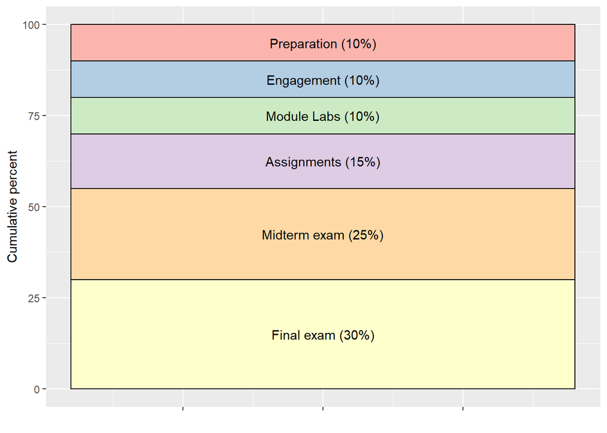

### Preparation (10%)

To begin each module, you will be expected to complete the assigned textbook reading, watch the assigned videos in Canvas and take complete notes on the videos prior to class.

- You may take notes on your own or use the guided video notes (found in the coursepack). Video notes will be checked off at the start of class each day.
- The lowest (1) preparation (video note) score will be dropped at the end of the semester.
- OPTIONAL: You can complete video/reading quizzes, which are found on Gradescope, to check your understanding at any point during a module. You can check your answers after each question by using the Save button. If an explanation appears after you have saved your answer, that indicates your answer was correct.
- Video notes will be due checked **at the beginning of each class day**.

### Engagement (10%)

Every class day, you will meet with your classmates and instructor team to work through that day’s coursepack group activity. Scores on these exit tickets make up this portion of your grade.

### Module Labs (10%)

After a module has been completed, you will meet with your classmates and instructor team to work through a RStudio group lab, which is provided in your coursepack and will be completed during class time. The lab will reinforce the topics learned in the activities but with the use of RStudio for exploring and analyzing data.

- Each group will turn in selected questions from the lab to Gradescope. Labs are due **at 11:59pm MST on dates indicated on the course calendar**.
- The lowest (1) lab grade will be dropped at the end of the semester.
- Please review the discussion of the use of AI on labs.

### Assignments (15%)

You will complete weekly assignments in [Gradescope](https://www.gradescope.com/). These should be completed individually (meaning all answers should be written in your own words), but you may use your classmates, tutors, or your instructor/co-instructor/TA for assistance.

- Weekly assignments are due **Wednesdays at 11:59pm MST each week, covering the previous week’s content**.
- The lowest (1) assignment grade will be dropped at the end of the semester.
- Please review the discussion of the use of AI on assignments.

### Midterm exam (25%)

There will be one midterm exam which will be taken in class during your normal in-class time. The midterm will consist of both a group (first hour of class) and individual (second hour of class) component. Further details, resources, and instructions for each exam will be posted the week prior to the exam in Canvas.

- **Summer Session I: Midterm exam on June 8**
- **Summer Session II: Midterm exam on July 16**

#### *Group portion*:

- The group portion of the midterm is worth 20% of your midterm exam grade.
- Group midterm exam is open book, open notes, but you may not use AI.
- You will be allowed a calculator on the group midterm exam.
- You **will** be required to use RStudio on the group midterm exam.
- **If you miss more than 1 day of class within unit 1 (start of semester until exam date) without communicating with your section instructor and group-mates, you must complete the group exam individually.**

#### *Individual portion*:

- Individual portion of the midterm will be worth 80% of your midterm exam grade.
- Individual midterm exam are closed book, closed notes.
- A formula sheet will be provided to use during the exam.
- You will also be allowed to create your own sheet of notes to use during the exam (8.5 by 11 in, must be handwritten).
- You will be allowed a calculator on the individual midterm exam.
- You will **not** be required to use RStudio on the individual midterm exam.

### Final exam (30%)

The final exam is cumulative, but will be more heavily weighted towards Unit 2 material and is worth 30% of the course grade. The final exam will be taken in class during your normal in-class time. The final exam has a group (first hour of class) and individual (second hour of class) component. Further details, resources, and instructions for each exam will be posted the week prior to the exam in Canvas.

- **Summer Session I: Group final exam on June 23; Individual final exam on June 25**
- **Summer Session II: Group final exam on August 4; Individual final exam on August 6**

#### *Group portion*:

- The group portion of the final exam will be worth 20% of your exam grade.
- The group final exam is open book, open notes.
- You will be allowed a calculator on the group final exam.
- You **will** be required to use RStudio on the group final exam.
- **If you miss more than 1 day of class in Unit 2 (midterm exam date until final exam date) without communicating with your section instructor and group-mates, you must complete the group final individually.**

#### *Individual portion*:

- The individual portion of the final exam will be worth 80% of your exam grade.
- The individual final exam is closed book.
- A formula sheet will be provided to use during the exam.
- You will also be allowed to create your own sheet of notes to use during the exam (8.5 by 11 in, must be handwritten)
- You will be allowed a calculator on the individual final exam.
- You will **not** be required to use RStudio on the individual final exams.

### Letter grades

Final course grades will be determined according to the following scale.

| Letter Grade | Weighted Score |
| --- | --- |
| A | 93-100% |
| A- | 90-92.99% |
| B+ | 87-89.99% |
| B | 83-86.99% |
| B- | 80-82.99% |
| C+ | 77-79.99% |
| C | 70-76.99% |
| D | 60-69.99% |
| F | <59.99% |

The grade cutoffs may be shifted *downward* at the end of the semester based on student performance (never upward).

# Late work policies

Note: we **highly** recommend saving your answers for each question while you complete all work in Gradescope. This will ensure you can return to labs, exit tickets, or assignments at a later date without fear of losing any progress. Additionally, Gradescope will automatically submit any saved work when the due date passes, ensuring you earn up to full credit for all problems completed on time.

- **Assignments**:
  - You may take the assignments in Gradescope as many times as you like up until the due date using the Resubmit button to re-open a quiz.
  - Extensions on assignments are not given unless extenuating circumstances are present which are communicated to your instructor
- **Exit Tickets and Labs**:
  - You may edit the exit tickets and labs in Gradescope as many times as you like up until the due date using the Resubmit button to re-open an assessment.
  - If you miss class and email your section instructor about your absence **the day class is missed**, you will be given a 24-hour extension to complete the exit ticket or lab.
  - If possible, it is highly recommended to attend class virtually (via video conferencing with your group) to complete the lab or exit ticket with your team.
  - Further extensions on exit tickets or labs, or when an absence is not communicated the day class is missed, are not given unless extenuating circumstances are present. Please email your instructor if you feel your missed exit ticket or lab falls into this category.
- **Preparation/Video Notes**:
  - Video notes are due the beginning of each class period.
  - If you are absent the day a new module is started, you may turn in your video notes the first day you attend class in that module for up to full credit.
- **Exams**:
  - Students that are in quarantine but healthy enough to take the exam should email your instructor to make alternative arrangements. The group exams may be taken remotely and proctored via WebEx but all individual exams must be taken in person.
  - If you are ill to the point of not being able to take the exam, please email your instructor to make alternative arrangements.
  - Students who miss the exam without contacting the instructor prior to the exam will receive a zero on the exam.
  - Work is not a legitimate reason for an exam absence.

# COVID-19 policies and health-related class absences

Face masks are recommended, but not required, for students, faculty and staff indoors on campus.

Please evaluate your own health status regularly and refrain from attending class and other on-campus events if you are ill. MSU students who miss class due to illness will be given opportunities to access course materials online. You are encouraged to seek appropriate medical attention for treatment of illness. In the event of contagious illness, please do not come to class or to campus to turn in work. Instead notify us by email about your absence as soon as practical, so that accommodations can be made. Please note that documentation (a Doctor’s note) for medical excuses is not required. MSU University Health Partners–as part their commitment to maintain patient confidentiality, to encourage more appropriate use of healthcare resources, and to support meaningful dialogue between instructors and students–does not provide such documentation.

# Diversity and inclusivity

Respect for Diversity: It is our intent that students from all diverse backgrounds and perspectives be well-served by this course, that students’ learning needs be addressed both in and out of class, and that the diversity that students bring to this class be viewed as a resource, strength and benefit. It is our intent to present materials and activities that are respectful of diversity: gender identity, sexual orientation, disability, age, socioeconomic status, ethnicity, race, religion, culture, perspective, and other background characteristics. Your suggestions about how to improve the value of diversity in this course are encouraged and appreciated. Please let us know ways to improve the effectiveness of the course for you personally or for other students or student groups.

In addition, in scheduling exams, we have attempted to avoid conflicts with major religious holidays. If, however, we have inadvertently scheduled an exam or major deadline that creates a conflict with your religious observances, please let us know as soon as possible so that we can make other arrangements.

Support for Inclusivity: We support an inclusive learning environment where diversity and individual differences are understood, respected, appreciated, and recognized as a source of strength. We expect that students, faculty, administrators and staff at MSU will respect differences and demonstrate diligence in understanding how other peoples’ perspectives, behaviors, and worldviews may be different from their own.

# Policy on academic misconduct

Students in an academic setting are responsible for approaching all assignments with rigor, integrity, and in compliance with the University Code of Student Conduct. This responsibility includes:

1. consulting and analyzing sources that are relevant to the topic of inquiry;
2. clearly acknowledging when they draw from the ideas or the phrasing of those sources in their own writing;
3. learning and using appropriate citation conventions within the field in which they are studying; and
4. asking their instructor for guidance when they are uncertain of how to acknowledge the contributions of others in their thinking and writing.

When students fail to adhere to these responsibilities, they may intentionally or unintentionally “use someone else’s language, ideas, or other original (not common-knowledge) material without properly acknowledging its source” http://www.wpacouncil.org. When the act is intentional, the student has engaged in plagiarism.

Plagiarism is an act of academic misconduct, which carries with it consequences including, but not limited to, receiving a course grade of “F” and a report to the Office of the Dean of Students. Unfortunately, it is not always clear if the misuse of sources is intentional or unintentional, which means that you may be accused of plagiarism even if you do not intentionally plagiarize. If you have any questions regarding use and citation of sources in your academic writing, you are responsible for consulting with your instructor before the assignment due date. In addition, you can work with an MSU Writing Center tutor at any point in your writing process, including when you are integrating or citing sources. You can make an appointment and find citation resources at www.montana.edu/writingcenter.

**In STAT 216, assignments that include the same wording as another student, regardless of whether that student was cited in your sources, will be considered plagiarism and will be treated as such. Students involved in plagiarism on assignments (all parties involved) will receive a zero grade on that assignment. The second offense will result in a zero on that assignment, and the incident will be reported to the Dean of Students. Academic misconduct on an exam will result in a zero on that exam and will be reported to the Dean of Students, without exception.**

[More information about Academic Misconduct from the Dean of Students](https://www.montana.edu/deanofstudents/academicmisconduct/academicmisconduct.html)

# Policy on intellectual property

This syllabus, course lectures and presentations, and any course materials provided throughout this term are protected by U.S. copyright laws. Students enrolled in the course may use them for their own research and educational purposes. However, reproducing, selling or otherwise distributing these materials without written permission of the copyright owner is expressly prohibited, including providing materials to commercial platforms such as Chegg or CourseHero. Doing so may constitute a violation of U.S. copyright law as well as MSU’s Code of Student Conduct.

# Policy on the use of AI language models

This class will strive to create an environment that fosters learning, critical thinking, and effective communication. To achieve these goals, **we do not allow the use of ChatGPT or similar tools for all work completed within class**.

While ChatGPT and other language models can be powerful and useful tools in certain contexts, relying on them for this course undermines the learning objectives. We want you to develop your skills in independent thinking, problem-solving, and engagement with the subject matter. By restricting the use of AI language models, you will utilize your knowledge, creativity, and critical analysis to complete your exit tickets, labs, and exams and actively participate in class discussions.

We also understand that technology plays an increasingly prominent role in various aspects of our lives, and acknowledge its potential benefits. Therefore, **you may utilize generative AI language models, including ChatGPT, as a resource to support your work outside of class** . *While the AI language models can help refine your writing and coding, it is important to remember that it is an AI system and not a substitute for your critical thinking and creativity. Due to the nature of statistics and this course, an AI-generated answer may be incomplete, overly complex, or even incorrect.* If you do not understand a concept or a question asked, we *highly* recommend visiting the [Math and Stats Center](https://math.montana.edu/undergrad/msc/), emailing or visiting with a member of your instructional team, posting to Canvas discussions, or using the search feature within the online textbook before turning to Google or AI.

If you choose to use AI, apply it as a supplement and do not rely solely on its suggestions. Ultimately, you are responsible for the content and quality of your work. Therefore, you should critically evaluate AI outputs for accuracy, potential bias, and relevancy. When utilizing AI language models, it is essential to ensure that your writing and coding remains original and properly attributed, including citing outputs or text generated by AI. **If you choose to use AI language models to assist you on labs or assignments, you must cite the source used. Failure to do so will result in earning a 0 on all problems in which AI language models usage has been detected.** Please see the How to cite ChatGPT in MLA Style [resource](https://style.mla.org/citing-generative-ai/).

If you have any questions or concerns regarding using AI language models for assignments but not on exit tickets, labs, or exams, please discuss them with us.